# a5

Tan Hong Ming

October 29, 2017

### 1. Implement Bagging on the data generating model of Example 2.8 (use the file Example2.8_Bootstrap.html): (1) set parameter sigma=0.5, N=50; (2) build and visualize one tree model (you can use any software package) on one data sample; (3) manually generate 1000 bootstrap samples and build a bagging model, visualize the resulted prediction on test data, and measure the MSE, Bias, and Variance.

#### Using the data generating model of Example 2.8, as well as creating out of sample data, we have the following code.

```r
#Data generating model
set.seed(135790)
# static parameters
x.min <- -1
x.max <- 1
sigma <- 0.5
# function for generating data
data.gen <- function(N=2) {
  x <- runif(n=N, min=x.min, max=x.max)
  f.x <- sin(pi * x)
  epsilon <- rnorm(n=N, mean=0, sd=sigma)
  y <- f.x + epsilon
  return(data.frame(x=x, y=y))
}

#Out of Sample data
M <- 10000
x.out <- sort(runif(n=M, min=x.min, max=x.max))  # order the data points by x for easy plots
f.x.out <- sin(pi * x.out)
y.out <- f.x.out + rnorm(n=M, mean=0, sd=sigma)
x.test=data.frame(x=x.out)
```

#### Generating one data sample size N=50, sigma = 0.5

```r
N=50;
data0 = data.gen(N=N);
```

#### Build one tree using ‘tree’ library.

```r
#Buiding a tree
tree1 <- tree(y ~ x, data=data0)
summary(tree1)
```

```
##
## Regression tree:
## tree(formula = y ~ x, data = data0)
## Number of terminal nodes:  5
## Residual mean deviance:  0.2014 = 9.064 / 45
## Distribution of residuals:
##     Min.  1st Qu.   Median     Mean  3rd Qu.     Max.
## -0.91150 -0.26760 -0.03412  0.00000  0.25330  1.20400
```

#### and plot decision tree…

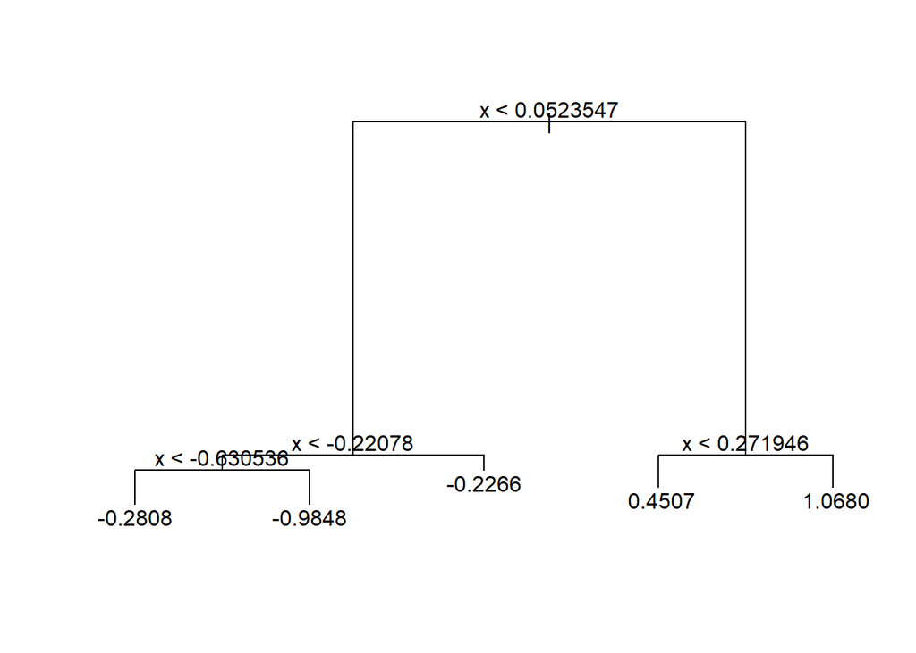

```r
# plot the fitted tree
plot(tree1)
text(tree1)
```

#### Plot the partitions

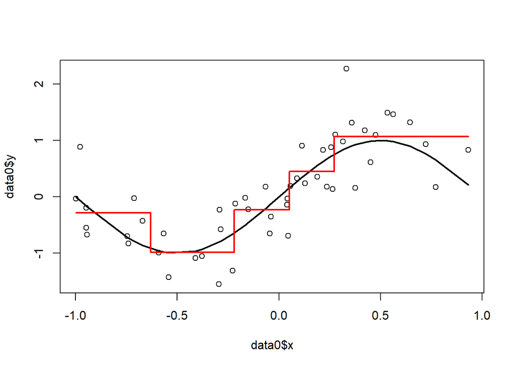

```r
# plot the partition
plot(data0$x, data0$y)
x <- data0$x[order(data0$x)]
f.x <- sin(pi * x)
lines(x, f.x, lwd=2)
partition.tree(tree1, lwd=2, col="red", add=T)
```

### bootstrapping

#### function for generating Bootstrap data sample

```r
data.bootstrap <- function(data) {
  index <- sample(N, N, replace=TRUE)
  return(data[index, ])
}
```

#### generating 1000 trees and getting the predictions

```r
RUN=1000;
predictions = matrix(rep(0,RUN*M),nrow = RUN, ncol=M)
#generate 1000 bootstrap samples and getting predictions
for (run in 1:RUN) {
  data <- data.bootstrap(data = data0);
  treeBS = tree(y~x,data=data);
  predictions[run,] = predict(treeBS,x.test);
}
y.test = colMeans(predictions)
```

#### visualizing the non-random forest

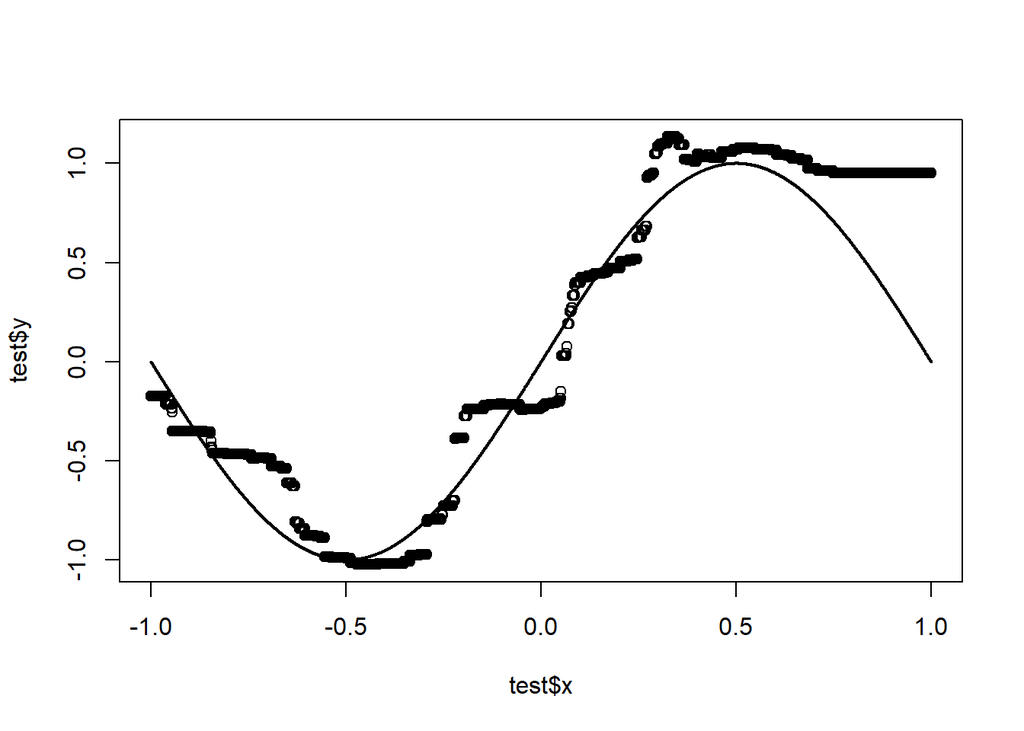

```r
test = data.frame(x=x.test, y=y.test)
plot(test$x, test$y);
lines(x.out, f.x.out, lwd=2);
```

#### Measuring MSE, Bias, and Variance

```r
g_D_x <- predictions;
g_bar_x <-colMeans(g_D_x)

bias = mean((g_bar_x-f.x.out)^2);
var = mean((t(g_D_x)-g_bar_x)^2);
MSE = mean((t(g_D_x)-y.out)^2);
```

The final numbers are as follows.

| Bias | Variance | MSE |  |
| --- | --- | --- | --- |
| 0.0676821 | 0.0616438 | 0.3769345 |  |

### 2. Show that as the number of bootstrap samples B gets large, the OOB error estimate for a random forest approaches its LOOCV error estimate, and that in the limit, the identity is exact.

We first prove that each bootstrap sample takes about $2/3$ of the original sample.

The probability of an observation $(x_i,y_i)$ not being selected from selecting from sample of size $N$ is $(1-\frac{1}{N})$. For a bootstrap sample of size $N$, the probability of not selecting $(x_i,y_i)$ is $(1-\frac{1}{N})^N\rightarrow\frac{1}{e}\approx\frac{1}{3}$ as $N\rightarrow\infty$. Hence, each bootstrap sample takes about $1-\frac{1}{3}=\frac{2}{3}$ of the observations.

Let $X$ be a sample of size $N$. Let $X_t$ be a sample drawn with repetition from $X$, used to build tree $t$, then $X_t$ is a bootstrap sample of $X$ for tree $t$. Let $O_t = X \setminus X_t$ be the set of out-of-bag elements of tree $t$. Then we have

$$\begin{align*}
\text{OOB Error}&=\frac{\sum\limits_{t=1}^{B}\sum\limits_{i=1}^{|O_t|} Error(y_i,f_t(x_i))}{\sum\limits_{t=1}^{B}|O_t|}
\end{align*}$$

To compute the LOOCV, we partition $X$ into $N$ partitions $X=\{X_1,X_2,\dots,X_N\}$, $X_i\cap X_j=\phi$, $|X_i|=1$ since the sample size is $N$. Let $S_t=X\setminus{X_t}$ be the sample used for creating the random forest $t$. Then we have

$$\begin{align*}
\text{LOOCV error}=\frac{\sum\limits_{t=1}^{N}Error(y_t,f_{S_t}(x_t))}{N}
\end{align*}$$
We also proof that with probability 1 each element is selected in at least one of the bootstrap samples. The probability of an observation $(x_i,y_i)$ not being selected for a particular bootstrap sample is $(1-\frac{1}{N})^N$. Hence, for $B$ number of bootstrap samples, the probability of $(x_i,y_i)$ not being selected at all is $(1-\frac{1}{N})^{NB}\rightarrow0$ as $B\rightarrow\infty$. Now we are ready to show the convergence of the OOB Error.
$$\begin{align*}
\lim_{B\rightarrow\infty}\text{OOB Error}&=\frac{\lim_{B\rightarrow\infty}\sum\limits_{t=1}^{B}\sum\limits_{i=1}^{|O_t|} Error(y_i,f_t(x_i))}{\lim_{B\rightarrow\infty}\sum\limits_{t=1}^{B}|O_t|}\\
&=\frac{\frac{1}{3}\sum\limits_{i=1}^{N} Error(y_i,f_t(x_i))}{\frac{1}{3}N}\\
&=\frac{\sum\limits_{i=1}^{N} Error(y_i,f_t(x_i))}{N}
\end{align*}$$